# Data Mining Assignment

by Jad Obeid, Marwa Ghraizi and Patrick Nohra

(November 14, 2021)

In the following report, we will first explore data representing car acceptability based on multiple features. After that, we will perform and analyze four machine learning models to predict car acceptability: Logistic Regression, LDA, QDA and KNN.

# Exploring the Data

```r
data=read.csv('C:/Users/Patss/Desktop/Fall2021/Data Mining/Starting R/Training R/DataAssign2.csv', stringsAsFactors  =FALSE)
summary(data)
```

```
##       V1                 V2                 V3                 V4
##  Length:260         Length:260         Length:260         Length:260
##  Class :character   Class :character   Class :character   Class :character
##  Mode  :character   Mode  :character   Mode  :character   Mode  :character
##       V5                 V6                 V7
##  Length:260         Length:260         Length:260
##  Class :character   Class :character   Class :character
##  Mode  :character   Mode  :character   Mode  :character
```

## Cleaning the Data

For better readability, we changed the column names into their corresponding predictors’ names (Price, MaintenancePrice, NbDoors, PersonsCapacity, LuggageSize and Safety) as well as changing the response column into “Acceptability”.

```r
names(data)= c('Price', 'MaintenancePrice', 'NbDoors', 'PersonsCapacity', 'LuggageSize', 'Safety', 'Acceptability')
summary(data)
```

```
##     Price           MaintenancePrice     NbDoors          PersonsCapacity
##  Length:260         Length:260         Length:260         Length:260
##  Class :character   Class :character   Class :character   Class :character
##  Mode  :character   Mode  :character   Mode  :character   Mode  :character
##  LuggageSize           Safety          Acceptability
##  Length:260         Length:260         Length:260
##  Class :character   Class :character   Class :character
##  Mode  :character   Mode  :character   Mode  :character
```

```r
#summary(data$NbDoors)
```

Seeing that the quantitative predictors **`NbDoors & PersonsCapacity`** contain non numeric data values (5more and more) we used the **`ifelse()`** function followed by the **`as.numeric()`** function to assign the data type as consistent numbers.

```r
data$NbDoors <- ifelse(data$NbDoors == '5more', '5', data$NbDoors)
data$NbDoors = as.numeric(data$NbDoors)
summary(data$NbDoors)
```

```
##    Min. 1st Qu.  Median    Mean 3rd Qu.    Max.
##     2.0     3.0     4.0     3.6     5.0     5.0
```

```r
data$PersonsCapacity <- ifelse(data$PersonsCapacity == 'more', '6', data$PersonsCapacity)
data$PersonsCapacity = as.numeric(data$PersonsCapacity)
```

## Factors Ordering

```r
cat("Original factor levels:",levels(data$Price))
```

```
## Original factor levels:
```

```r
data$Price=factor(data$Price, levels = c("low","med","high","vhigh"))
cat("Newly ordered factor levels:",levels(data$Price))
```

```
## Newly ordered factor levels: low med high vhigh
```

```r
data$MaintenancePrice=factor(data$MaintenancePrice, levels = c("low","med","high","vhigh"))
data$LuggageSize=factor(data$LuggageSize, levels = c("small","med","big"))
data$Safety=factor(data$Safety, levels = c("low","med","high"))


data$Acceptability=factor(data$Acceptability, levels = c("bad","good"))
```

## Plotting Categorical Predictors

Creating frequency tables

```r
PriceTable = table(data$Price,data$Acceptability)
MaintenancePriceTable = table(data$MaintenancePrice,data$Acceptability)
LuggageTable = table(data$LuggageSize,data$Acceptability)
SafetyTable = table(data$Safety,data$Acceptability)
```

## Mosaic Plots

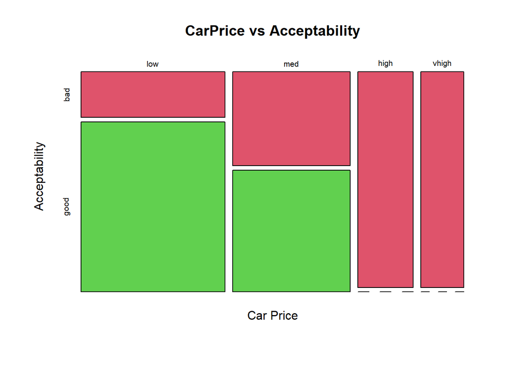

```r
mosaicplot(PriceTable,main="CarPrice vs Acceptability", xlab = "Car Price",ylab="Acceptability", col=c(2,3))
```

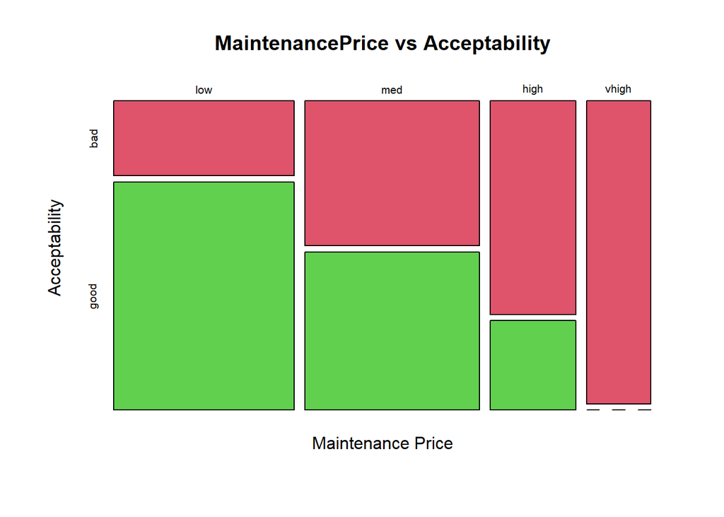

```r
mosaicplot(MaintenancePriceTable,main="MaintenancePrice vs Acceptability", xlab = "Maintenance Price",ylab="Acceptability", col=c(2,3))
```

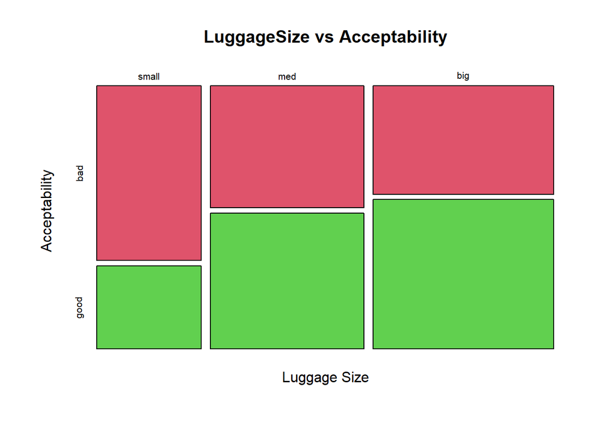

```r
mosaicplot(LuggageTable,main="LuggageSize vs Acceptability", xlab = "Luggage Size",ylab="Acceptability", col=c(2,3))
```

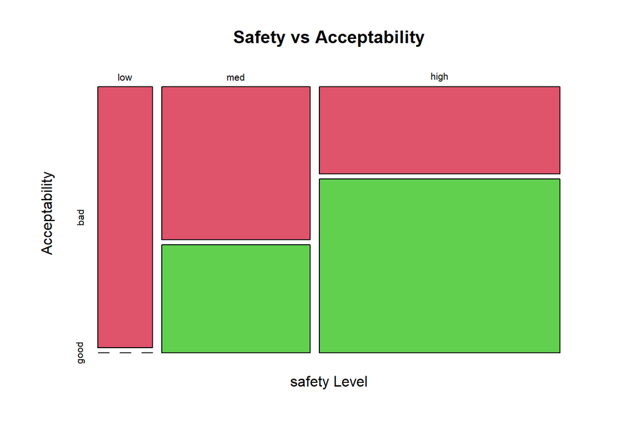

```r
mosaicplot(SafetyTable,main="Safety vs Acceptability", xlab = "safety Level",ylab="Acceptability", col=c(2,3))
```

## Boxplots for the other 2 predictors

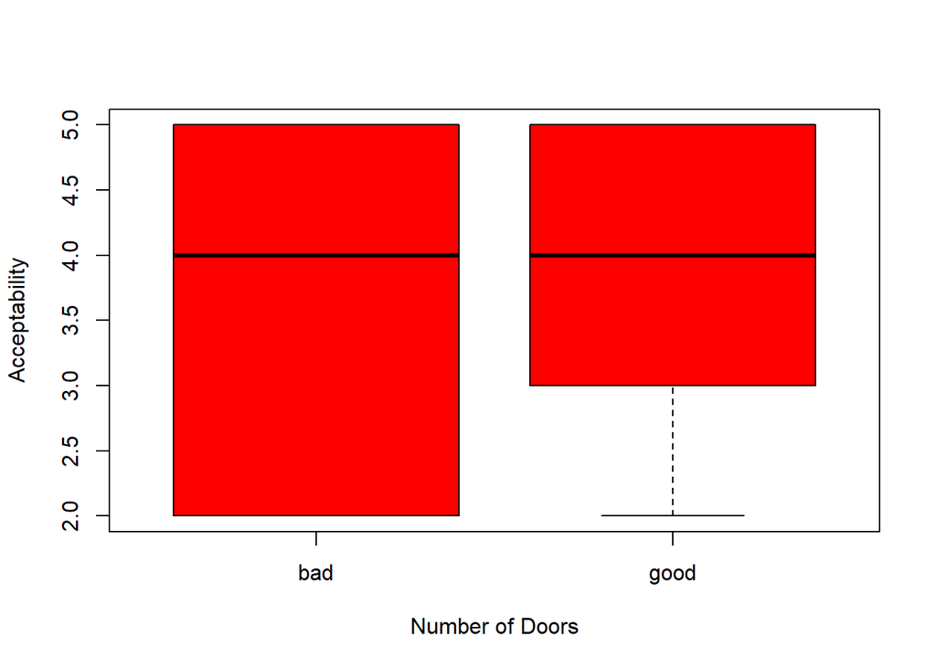

```r
plot(data$Acceptability, data$NbDoors, col="red", varwidth=T, xlab="Number of Doors", ylab="Acceptability")
```

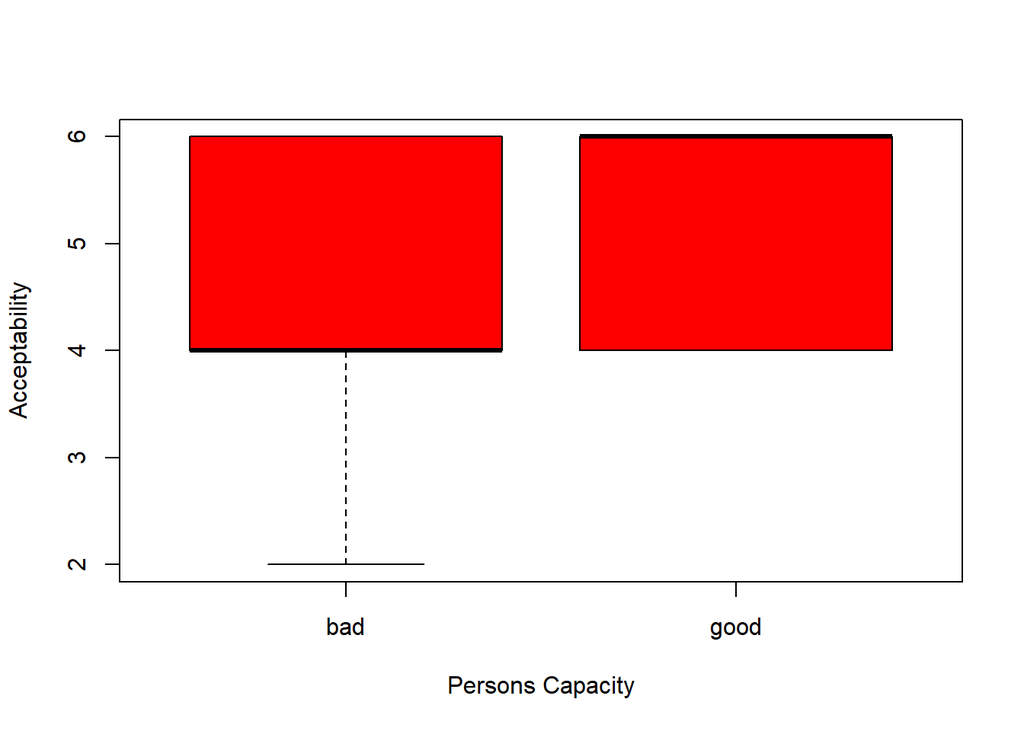

```r
plot(data$Acceptability, data$PersonsCapacity, col="red", varwidth=T, xlab="Persons Capacity", ylab="Acceptability")
```